# Tema 9 Máster en Machine Learning

Ejercicio Obligatorio 2

Illya Bjazevic

2025-09-01

*Datos Auto*

Analiza el consumo de gasolina para 392 vehículos según sus características. Los datos se encuentran en el objeto Auto del paquete ISLR y fueron utilizados en 1983 en la American Statistical Association Exposition.

Sigue los siguientes pasos:

1. Observa y grafica los datos.
2. Transforma los datos cuando sea necesario.
3. Divide el conjunto de datos en uno de entrenamiento y otro de prueba.
4. Construye el modelo NN, grafica e interpreta el resultado.
5. Evalúa la performance del modelo NN.

### Parte 1: Observa y grafica los datos.

*En el Paso 1 del conjunto Auto, el código carga los datos y realiza un EDA básico: inspecciona la estructura y primeras filas para confirmar tipos y esquema (str(df), head(df), summary(df)), y grafica comparaciones como boxplots de MPG por origen y por cilindros; el propósito es diagnosticar la calidad y forma de las variables (distribuciones, rangos, posibles outliers y relaciones iniciales) para guiar las transformaciones del Paso 2 y preparar decisiones del pipeline de modelado posterior.*

```r
# 1.1) Cargar paquetes (instalar si es necesario)
suppressPackageStartupMessages({
  library(ggplot2)   # gráficos
  library(dplyr)     # manipulación de datos
  library(tidyr)     # pivot_longer para histogramas facetados
})

# 1.2) Cargar el dataset Auto desde ISLR2 (usar ISLR si ISLR2 no está presente)
if (requireNamespace("ISLR2", quietly = TRUE)) {
  data("Auto", package = "ISLR2")
  df <- ISLR2::Auto
} else if (requireNamespace("ISLR", quietly = TRUE)) {
  data("Auto", package = "ISLR")
  df <- ISLR::Auto
} else {
  stop("Please install package ISLR2 or ISLR to access the 'Auto' dataset.")
}

# 1.3) Estructura básica y vista previa
#     - Confirmar tipos de variables y ver algunas filas para entender el esquema
str(df)
```

```
## 'data.frame':    392 obs. of  9 variables:
##  $ mpg         : num  18 15 18 16 17 15 14 14 14 15 ...
##  $ cylinders   : int  8 8 8 8 8 8 8 8 8 8 ...
##  $ displacement: num  307 350 318 304 302 429 454 440 455 390 ...
##  $ horsepower  : int  130 165 150 150 140 198 220 215 225 190 ...
##  $ weight      : int  3504 3693 3436 3433 3449 4341 4354 4312 4425 3850 ...
##  $ acceleration: num  12 11.5 11 12 10.5 10 9 8.5 10 8.5 ...
##  $ year        : int  70 70 70 70 70 70 70 70 70 70 ...
##  $ origin      : int  1 1 1 1 1 1 1 1 1 1 ...
##  $ name        : Factor w/ 304 levels "amc ambassador brougham",..: 49 36 231 14 161 141 54 223 241 2 ...
##  - attr(*, "na.action")= 'omit' Named int [1:5] 33 127 331 337 355
##   ..- attr(*, "names")= chr [1:5] "33" "127" "331" "337" ...
```

```r
dplyr::glimpse(df)
```

```
## Rows: 392
## Columns: 9
## $ mpg          <dbl> 18, 15, 18, 16, 17, 15, 14, 14, 14, 15, 15, 14, 15, 14, 2…
## $ cylinders    <int> 8, 8, 8, 8, 8, 8, 8, 8, 8, 8, 8, 8, 8, 8, 4, 6, 6, 6, 4, …
## $ displacement <dbl> 307, 350, 318, 304, 302, 429, 454, 440, 455, 390, 383, 34…
## $ horsepower   <int> 130, 165, 150, 150, 140, 198, 220, 215, 225, 190, 170, 16…
## $ weight       <int> 3504, 3693, 3436, 3433, 3449, 4341, 4354, 4312, 4425, 385…
## $ acceleration <dbl> 12.0, 11.5, 11.0, 12.0, 10.5, 10.0, 9.0, 8.5, 10.0, 8.5, …
## $ year         <int> 70, 70, 70, 70, 70, 70, 70, 70, 70, 70, 70, 70, 70, 70, 7…
## $ origin       <int> 1, 1, 1, 1, 1, 1, 1, 1, 1, 1, 1, 1, 1, 1, 3, 1, 1, 1, 3, …
## $ name         <fct> chevrolet chevelle malibu, buick skylark 320, plymouth sa…
```

```r
head(df)
```

```
##   mpg cylinders displacement horsepower weight acceleration year origin
## 1  18         8          307        130   3504         12.0   70      1
## 2  15         8          350        165   3693         11.5   70      1
## 3  18         8          318        150   3436         11.0   70      1
## 4  16         8          304        150   3433         12.0   70      1
## 5  17         8          302        140   3449         10.5   70      1
## 6  15         8          429        198   4341         10.0   70      1
##                        name
## 1 chevrolet chevelle malibu
## 2         buick skylark 320
## 3        plymouth satellite
## 4             amc rebel sst
## 5               ford torino
## 6          ford galaxie 500
```

```r
summary(df)
```

```
##       mpg          cylinders      displacement     horsepower        weight
##  Min.   : 9.00   Min.   :3.000   Min.   : 68.0   Min.   : 46.0   Min.   :1613
##  1st Qu.:17.00   1st Qu.:4.000   1st Qu.:105.0   1st Qu.: 75.0   1st Qu.:2225
##  Median :22.75   Median :4.000   Median :151.0   Median : 93.5   Median :2804
##  Mean   :23.45   Mean   :5.472   Mean   :194.4   Mean   :104.5   Mean   :2978
##  3rd Qu.:29.00   3rd Qu.:8.000   3rd Qu.:275.8   3rd Qu.:126.0   3rd Qu.:3615
##  Max.   :46.60   Max.   :8.000   Max.   :455.0   Max.   :230.0   Max.   :5140
##
##   acceleration        year           origin                      name
##  Min.   : 8.00   Min.   :70.00   Min.   :1.000   amc matador       :  5
##  1st Qu.:13.78   1st Qu.:73.00   1st Qu.:1.000   ford pinto        :  5
##  Median :15.50   Median :76.00   Median :1.000   toyota corolla    :  5
##  Mean   :15.54   Mean   :75.98   Mean   :1.577   amc gremlin       :  4
##  3rd Qu.:17.02   3rd Qu.:79.00   3rd Qu.:2.000   amc hornet        :  4
##  Max.   :24.80   Max.   :82.00   Max.   :3.000   chevrolet chevette:  4
##                                                  (Other)           :365
```

```r
# 1.4) Revisión rápida de NAs (históricamente 'horsepower' tiene faltantes en algunas fuentes)
colSums(is.na(df))
```

```
##          mpg    cylinders displacement   horsepower       weight acceleration
##            0            0            0            0            0            0
##         year       origin         name
##            0            0            0
```

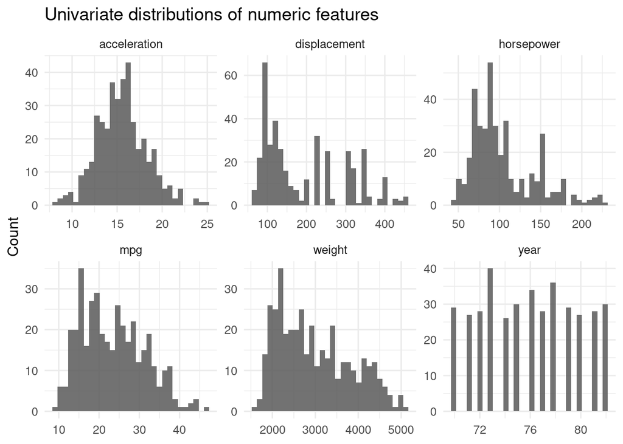

```r
# 1.5) Hacer factores explícitos para variables categóricas usadas en gráficos
#     - 'cylinders' y 'origin' son categóricas por naturaleza
df <- df %>%
  mutate(
    cylinders = as.factor(cylinders),
    origin = factor(origin, levels = c(1, 2, 3),
                    labels = c("American", "European", "Japanese"))
  )

# 1.6) Distribuciones univariadas — histogramas para variables numéricas
num_vars <- df %>% select(where(is.numeric)) %>% names()

df %>%
  select(all_of(num_vars)) %>%
  pivot_longer(everything(), names_to = "variable", values_to = "value") %>%
  ggplot(aes(x = value)) +
  geom_histogram(bins = 30, alpha = 0.85) +
  facet_wrap(~ variable, scales = "free", ncol = 3) +
  labs(title = "Univariate distributions of numeric features",
       x = NULL, y = "Count") +
  theme_minimal(base_size = 12)
```

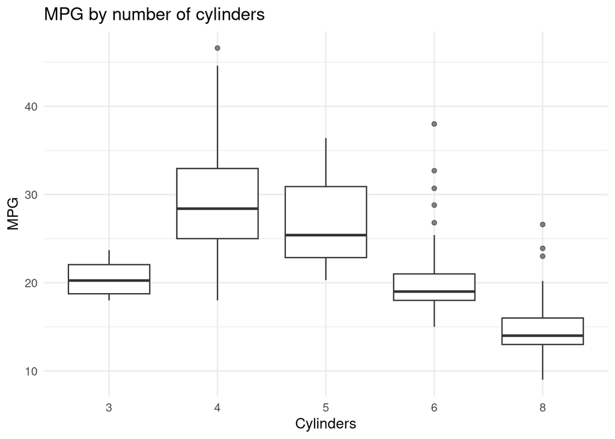

```r
# 1.7) Boxplots para comparar distribuciones entre categorías clave
#     - mpg por cylinders; mpg por origin
ggplot(df, aes(x = cylinders, y = mpg)) +
  geom_boxplot(outlier.alpha = 0.6) +
  labs(title = "MPG by number of cylinders", x = "Cylinders", y = "MPG") +
  theme_minimal(base_size = 12)
```

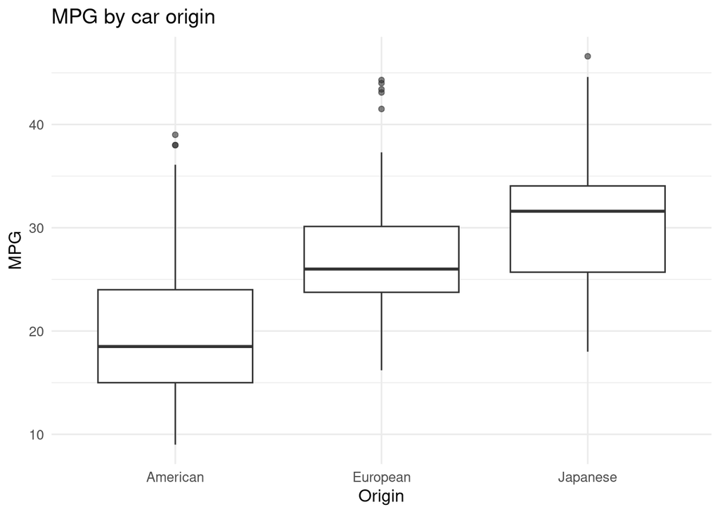

```r
ggplot(df, aes(x = origin, y = mpg)) +
  geom_boxplot(outlier.alpha = 0.6) +
  labs(title = "MPG by car origin", x = "Origin", y = "MPG") +
  theme_minimal(base_size = 12)
```

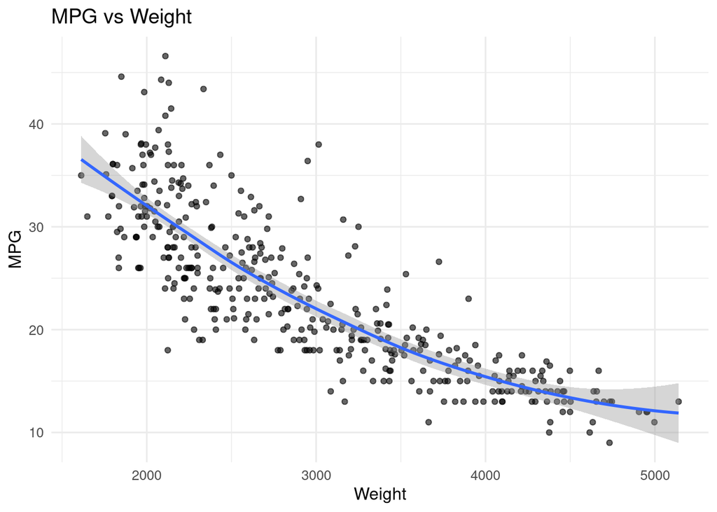

```r
# 1.8) Relaciones bivariadas clave con líneas suavizadas (chequeo de tendencia visual)
ggplot(df, aes(x = weight, y = mpg)) +
  geom_point(alpha = 0.6) +
  geom_smooth(method = "loess", se = TRUE) +
  labs(title = "MPG vs Weight", x = "Weight", y = "MPG") +
  theme_minimal(base_size = 12)
```

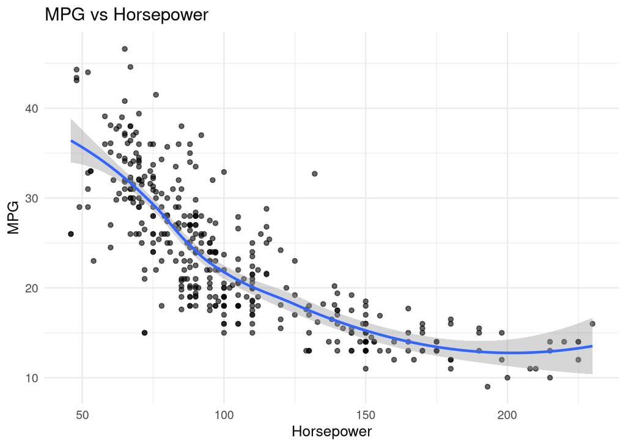

```r
ggplot(df, aes(x = horsepower, y = mpg)) +
  geom_point(alpha = 0.6) +
  geom_smooth(method = "loess", se = TRUE) +
  labs(title = "MPG vs Horsepower", x = "Horsepower", y = "MPG") +
  theme_minimal(base_size = 12)
```

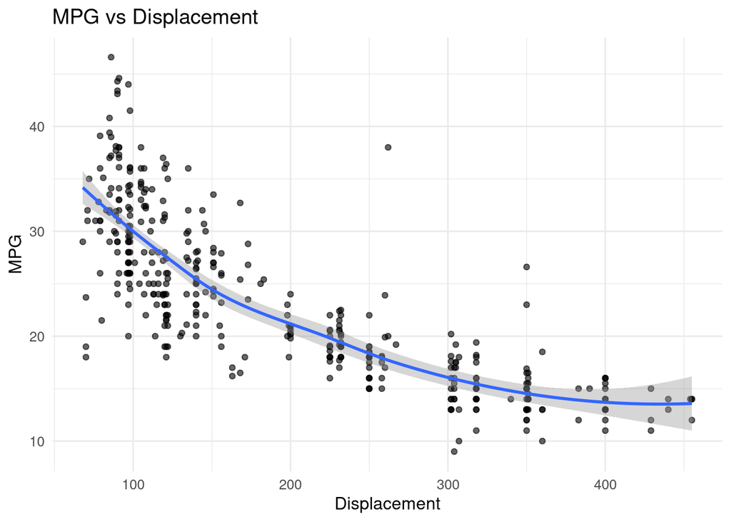

```r
ggplot(df, aes(x = displacement, y = mpg)) +
  geom_point(alpha = 0.6) +
  geom_smooth(method = "loess", se = TRUE) +
  labs(title = "MPG vs Displacement", x = "Displacement", y = "MPG") +
  theme_minimal(base_size = 12)
```

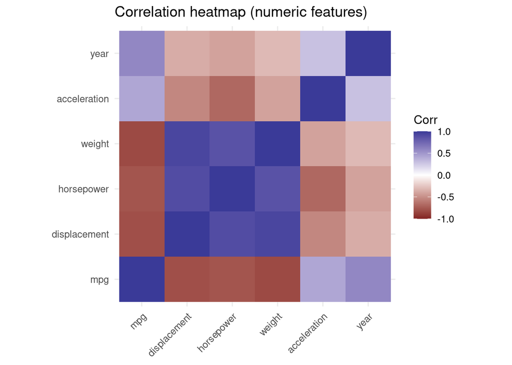

```r
# 1.9) Visión general de correlaciones (solo variables numéricas)
cor_mat <- cor(df %>% select(where(is.numeric)), use = "pairwise.complete.obs")
cor_long <- as.data.frame(as.table(cor_mat))
colnames(cor_long) <- c("Var1", "Var2", "Corr")

ggplot(cor_long, aes(Var1, Var2, fill = Corr)) +
  geom_tile() +
  scale_fill_gradient2(limits = c(-1, 1)) +
  coord_fixed() +
  labs(title = "Correlation heatmap (numeric features)", x = NULL, y = NULL) +
  theme_minimal(base_size = 12) +
  theme(axis.text.x = element_text(angle = 45, hjust = 1))
```

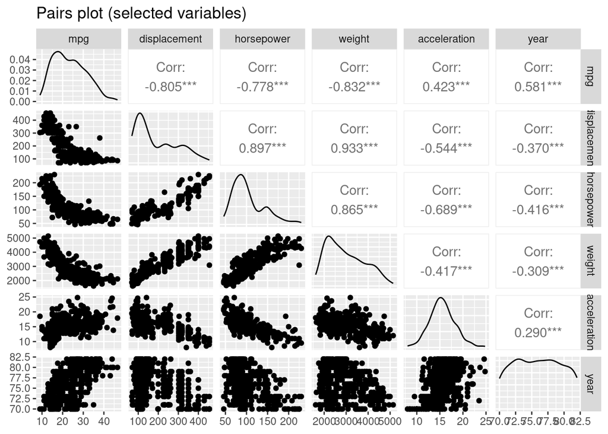

```r
# 1.10) Opcional: gráfico de pares si GGally está disponible (vista global rápida)
if (requireNamespace("GGally", quietly = TRUE)) {
  suppressPackageStartupMessages(library(GGally))
  df %>%
    select(mpg, displacement, horsepower, weight, acceleration, year) %>%
    GGally::ggpairs(title = "Pairs plot (selected variables)")
}
```

### Parte 2: Transforma los datos cuando sea necesario.

*El código valida que Auto de ISLR esté correctamente cargado, asegura que cylinders y origin queden como factores (solo si aún no lo estaban), comprueba que las variables continuas clave sean numéricas y que no existan valores faltantes, y produce dos salidas coherentes: auto_transformado (maestro limpio con name para trazabilidad) y auto_para_modelo (sin name, listo para los pasos siguientes). En esos pasos: split = separar en entrenamiento/validación/prueba para medir generalización sin fuga de información; escalado = estandarizar/normalizar numéricas para ponerlas en la misma escala y favorecer la convergencia en redes; modelado = entrenar el algoritmo elegido (p. ej., redes neuronales) y evaluar su desempeño.*

```r
# =========================
# PASO 2 — Transformaciones necesarias (SIN repetir el PASO 1)
# Precondición: en el PASO 1 ya se cargó 'df' (Auto) y se hizo EDA.
#               Aquí NO cargamos paquetes ni datos nuevamente.
#               Comentarios en español y con validaciones claras.
# =========================

# 0) Verificaciones mínimas (existencia de objeto y columnas esperadas)
if (!exists("df") || !is.data.frame(df)) {
  stop("Ejecuta el PASO 1 primero: debe existir 'df' en memoria con el dataset Auto.")
}
cols_esperadas <- c("mpg","cylinders","displacement","horsepower",
                    "weight","acceleration","year","origin","name")
faltan <- setdiff(cols_esperadas, names(df))
if (length(faltan) > 0) {
  stop("Faltan columnas en 'df': ", paste(faltan, collapse = ", "))
}

# 1) Asegurar tipos para uso en ML SIN rehacer lo del PASO 1
#    - En el PASO 1 ya se usaron factores para graficar ('cylinders' y 'origin').
#    - Aquí solo corregimos si NO quedaron como factores (por ejemplo, si vienes de otra fuente).
if (!is.factor(df$cylinders)) {
  df$cylinders <- as.factor(df$cylinders)
}
if (!is.factor(df$origin)) {
  # 'origin' viene codificado 1/2/3; etiquetamos si aún no tiene labels
  # (American, European, Japanese) respetando el orden clásico.
  niveles_ok <- c("American","European","Japanese")
  # Si ya es factor con esas etiquetas, no tocamos; si no, re-factorizamos.
  if (!all(levels(df$origin) %in% niveles_ok)) {
    # Si 'origin' fuera numérico o factor con niveles 1/2/3:
    df$origin <- factor(as.integer(df$origin),
                        levels = c(1,2,3),
                        labels = niveles_ok)
  }
}

# 2) Validación de numéricas críticas (sin convertir silenciosamente)
#    Aseguramos que las variables continuas claves estén en formato numérico.
num_crit <- c("mpg","displacement","horsepower","weight","acceleration","year")
no_num <- num_crit[!sapply(df[num_crit], is.numeric)]
if (length(no_num) > 0) {
  stop("Estas columnas deberían ser numéricas y no lo son: ",
       paste(no_num, collapse = ", "),
       ". Revisa el PASO 1 o el origen de los datos.")
}

# 3) Control de valores faltantes (QA): no imputamos aquí, solo verificamos
na_por_col <- colSums(is.na(df))
if (any(na_por_col > 0)) {
  stop("Hay NA en el dataset antes del modelado. Revisa 'na_por_col' para decidir imputación: \n",
       paste(names(na_por_col), na_por_col, sep="=", collapse=", "))
}

# 4) Preparar dos salidas:
#    - 'auto_transformado': maestro limpio (con 'name' para reportes/joins)
#    - 'auto_para_modelo' : dataset para entrenar (sin 'name' para evitar fuga de info)
auto_transformado <- df
auto_para_modelo  <- df[ , setdiff(names(df), "name")]

# 5) Mensajes de control (puedes comentar si no quieres imprimir)
cat("Columnas categóricas (factores) listas: cylinders ->", is.factor(df$cylinders),
    "; origin ->", is.factor(df$origin), "\n")
```

```
## Columnas categóricas (factores) listas: cylinders -> TRUE ; origin -> TRUE
```

```r
cat("NA por columna (debería ser todo 0): ",
    paste(names(na_por_col), na_por_col, sep="=", collapse=", "), "\n")
```

```
## NA por columna (debería ser todo 0):  mpg=0, cylinders=0, displacement=0, horsepower=0, weight=0, acceleration=0, year=0, origin=0, name=0
```

```r
cat("Dimensiones (con 'name'):", paste(dim(auto_transformado), collapse = " x "), "\n")
```

```
## Dimensiones (con 'name'): 392 x 9
```

```r
cat("Dimensiones (sin 'name'):", paste(dim(auto_para_modelo),  collapse = " x "), "\n")
```

```
## Dimensiones (sin 'name'): 392 x 8
```

```r
# Nota:
# - No se crean dummies aquí; eso se haría en el pipeline de modelado si el algoritmo lo exige.
# - El escalado/normalización de numéricas (p. ej. para redes neuronales) se hará en el PASO 3.
# - 'name' es un identificador textual; mantenerlo fuera de los predictores evita fuga de información.
```